# Vergleich von Gen-Signatur-Scoring-Methoden für PLA-Detektion

Aurelia Dersch

12.12.2025

```r
library(Seurat)
library(SeuratData)
library(AUCell)
library(UCell)
library(ggplot2)
library(patchwork)
library(dplyr)
library(tibble)

# Signatur Definition
# Später Platelet-Signatur hier einfügen
T.cell.signatures <- list(
  T_Aktiv_Sig = c("CD3E", "CD8A", "IFNG", "IL2RA")
)
```

## 1 Datenverarbeitung und Preprocessing

Wir verwenden den Seurat-Beispieldatensatz pbmc3k.final. Später wird er durch das finale PLA-Dataset ersetzt. Die Preprocessing-Schritte stellen sicher, dass die Daten für das Clustering und die Scoring-Methoden vorbereitet sind.

```r
data("pbmc3k.final")
pbmc <- pbmc3k.final

DefaultAssay(pbmc) <- "RNA"
pbmc <- DietSeurat(pbmc, assays = "RNA", misc = FALSE, images = FALSE)

pbmc <- NormalizeData(pbmc)
pbmc <- FindVariableFeatures(pbmc)
pbmc <- ScaleData(pbmc)
pbmc <- RunPCA(pbmc, features = VariableFeatures(object = pbmc))
pbmc <- RunUMAP(pbmc, dims = 1:10)
pbmc <- FindNeighbors(pbmc, dims = 1:10)
pbmc <- FindClusters(pbmc, resolution = 0.8)
```

```
## Modularity Optimizer version 1.3.0 by Ludo Waltman and Nees Jan van Eck
##
## Number of nodes: 2638
## Number of edges: 95965
##
## Running Louvain algorithm...
## Maximum modularity in 10 random starts: 0.8282
## Number of communities: 11
## Elapsed time: 0 seconds
```

```r
print(pbmc)
```

```
## An object of class Seurat
## 13714 features across 2638 samples within 1 assay
## Active assay: RNA (13714 features, 2000 variable features)
##  3 layers present: counts, data, scale.data
##  2 dimensional reductions calculated: pca, umap
```

## 2 Methode: AddModuleScore (Seurat)

### 2.1 Funktionsweise und Parameter

Diese Methode berechnet den Score als durchschnittliche Expression der Signatur-Gene minus der durchschnittlichen Expression von Kontroll-Genen. Die Kontroll-Gene werden zufällig ausgewählt, aber auf der Basis der Expression in Bins gematcht. Das soll zelluläre Biases (z.B. Zellgröße) korrigieren.

Wichtigste Parameter:

- `ctrl` (default: 100): Anzahl der Kontroll-Gene pro Signatur
- `nbin` (default: 24): Anzahl der Bins, in die Gene für das Matching eingeteilt werden

### 2.2 Scoring und Visualisierung

```r
pbmc <- AddModuleScore(
  pbmc,
  features = T.cell.signatures,
  name = "Seurat_Score"
)
score_name_seurat <- "Seurat_Score1"
```

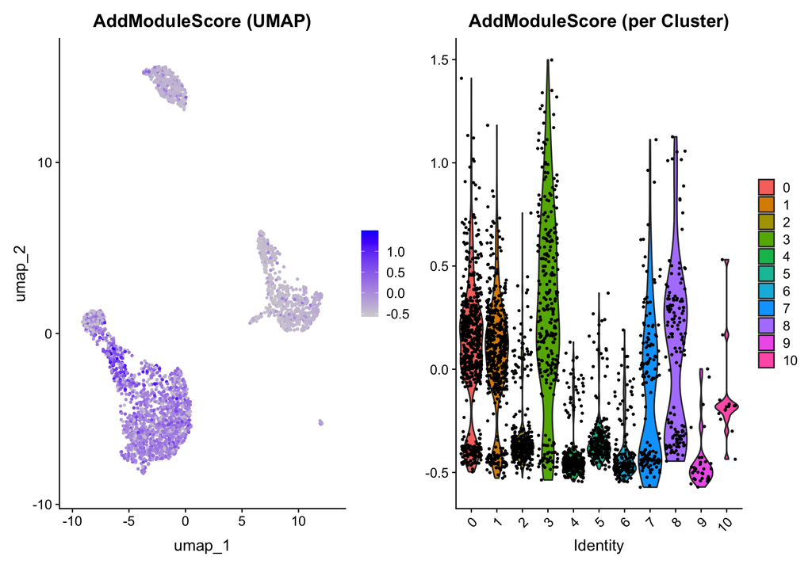

```r
# Visualisierung: UMAP und Verteilung pro Cluster
p1_seurat <- FeaturePlot(pbmc, features = score_name_seurat, reduction = "umap") +
  labs(title = "AddModuleScore (UMAP)")

p2_seurat <- VlnPlot(pbmc, features = score_name_seurat, group.by = "seurat_clusters", pt.size = 0.5, ncol = 1) +
  labs(title = "AddModuleScore (per Cluster)")

p1_seurat | p2_seurat
```

## 3 Methode: UCell

### 3.1 Funktionsweise und Parameter

UCell ist ein Rang-basierter Score (AUC), der durch eine Uniformity Correction weniger sensitiv gegenüber der Signaturgröße ist.

Wichtigster Parameter:

- `maxRank` (default ~1500): Der maximale Rang (Anzahl der Gene) in der zellspezifischen Gen-Rangliste, bis zu dem die AUC (Area Under the Curve) berechnet wird. Für ein schwaches PLA-Signal muss dieser Wert ggf. erhöht werden.

### 3.2 Experiment mit `maxRank` (Default vs. Modifiziert)

Wir berechnen den Score mit dem typischen Standardwert ≈1500 und einem modifizierten Wert ≈5000, um den Effekt zu zeigen.

```r
SIGNATURE_NAME <- names(T.cell.signatures)[1]

MAX_RANK_DEFAULT <- 1500
MAX_RANK_MODIFIED <- 5000

# DEFAULT BERECHNUNG
pbmc <- AddModuleScore_UCell(
  pbmc,
  features = T.cell.signatures,
  assay = "RNA",
  name = "UCellDefault",
  maxRank = MAX_RANK_DEFAULT
)
score_name_ucell_default_temp <- paste0(SIGNATURE_NAME, "UCellDefault")
pbmc$UCell_Default_Score <- pbmc[[score_name_ucell_default_temp, drop=TRUE]]
score_name_ucell_default <- "UCell_Default_Score"


# MODIFIZIERTE BERECHNUNG
pbmc <- AddModuleScore_UCell(
  pbmc,
  features = T.cell.signatures,
  assay = "RNA",
  name = "UCellModified",
  maxRank = MAX_RANK_MODIFIED
)

score_name_ucell_modified_temp <- paste0(SIGNATURE_NAME, "UCellModified")
pbmc$UCell_Modified_Score <- pbmc[[score_name_ucell_modified_temp, drop=TRUE]]
score_name_ucell_modified <- "UCell_Modified_Score"
```

### 3.3 Visualisierung

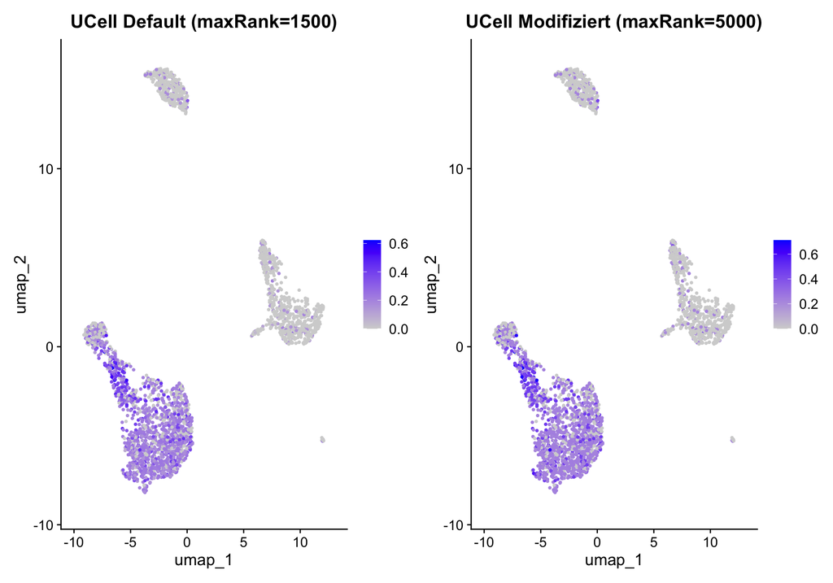

```r
p1_ucell <- FeaturePlot(pbmc, features = score_name_ucell_default, reduction = "umap") +
  labs(title = paste0("UCell Default (maxRank=", MAX_RANK_DEFAULT, ")"))

p2_ucell <- FeaturePlot(pbmc, features = score_name_ucell_modified, reduction = "umap") +
  labs(title = paste0("UCell Modifiziert (maxRank=", MAX_RANK_MODIFIED, ")"))

p1_ucell | p2_ucell
```

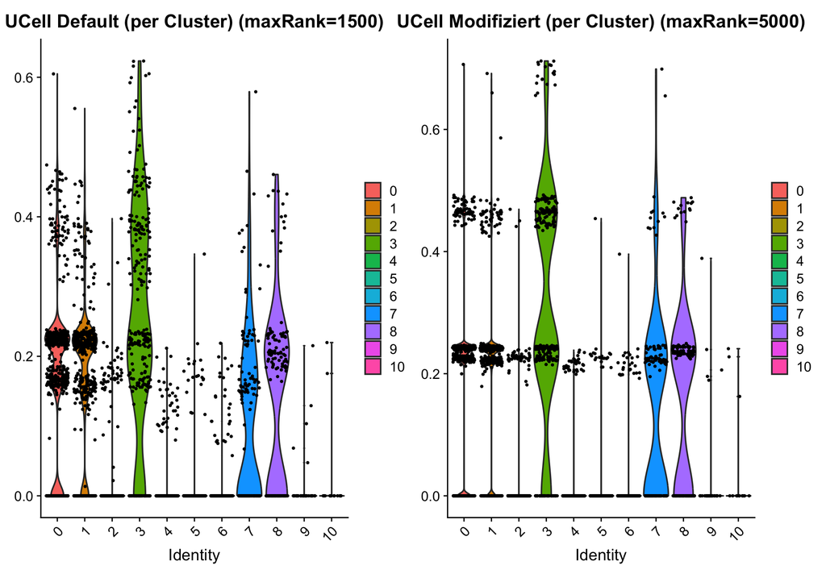

```r
# Per Cluster Verteilung des Modifizierten Scores
p3_ucell <- VlnPlot(pbmc, features = score_name_ucell_default, group.by = "seurat_clusters", pt.size = 0.5, ncol = 1) +
  labs(title = paste0("UCell Default (per Cluster) (maxRank=", MAX_RANK_DEFAULT, ")"))

p4_ucell <- VlnPlot(pbmc, features = score_name_ucell_modified, group.by = "seurat_clusters", pt.size = 0.5, ncol = 1) +
  labs(title = paste0("UCell Modifiziert (per Cluster) (maxRank=", MAX_RANK_MODIFIED, ")"))

p3_ucell | p4_ucell
```

## 4 Methode: AUCell

### 4.1 Funktionsweise und Parameter

AUCell ist ebenfalls ein Rang-basierter Score. Hier wird direkt mit den Ranks der Expression und der AUC gearbeitet.

- **Wichtigster Parameter:**
  - `aucMaxRank` (default: 5% der Gene): Der maximale Rang als Prozentsatz der Gesamt-Genanzahl, bis zu dem die AUC berechnet wird. Für ein schwaches PLA-Signal muss dieser Wert ggf. erhöht werden.

### 4.2 Experiment mit `aucMaxRank` (Default vs. Modifiziert)

Wir berechnen den Score mit dem Standardwert 5% und dem modifizierten Wert 20%.

```r
AUC_MAX_RANK_PC_DEFAULT <- 0.05
AUC_MAX_RANK_PC_MODIFIED <- 0.20

expression_matrix <- GetAssayData(pbmc, slot = "data")
cells_rankings <- AUCell_buildRankings(expression_matrix, plotStats=FALSE)
total_genes <- nrow(expression_matrix)

# DEFAULT BERECHNUNG
cells_AUC_default <- AUCell_calcAUC(T.cell.signatures, cells_rankings, aucMaxRank = AUC_MAX_RANK_PC_DEFAULT * total_genes)
pbmc$AUCell_Score_Default <- as.numeric(getAUC(cells_AUC_default)[1, ])
score_name_aucell_default <- "AUCell_Score_Default"


# MODIFIZIERTE BERECHNUNG
cells_AUC_modified <- AUCell_calcAUC(T.cell.signatures, cells_rankings, aucMaxRank = AUC_MAX_RANK_PC_MODIFIED * total_genes)
pbmc$AUCell_Score_Modified <- as.numeric(getAUC(cells_AUC_modified)[1, ])
score_name_aucell_modified <- "AUCell_Score_Modified"
```

### 4.3 Visualisierung

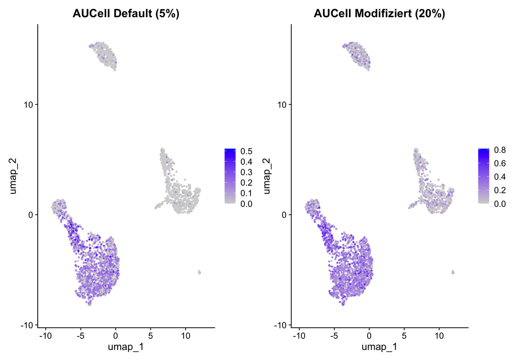

```r
p1_aucell <- FeaturePlot(pbmc, features = score_name_aucell_default, reduction = "umap") +
  labs(title = paste0("AUCell Default (", AUC_MAX_RANK_PC_DEFAULT*100, "%)"))

p2_aucell <- FeaturePlot(pbmc, features = score_name_aucell_modified, reduction = "umap") +
  labs(title = paste0("AUCell Modifiziert (", AUC_MAX_RANK_PC_MODIFIED*100, "%)"))

p1_aucell | p2_aucell
```

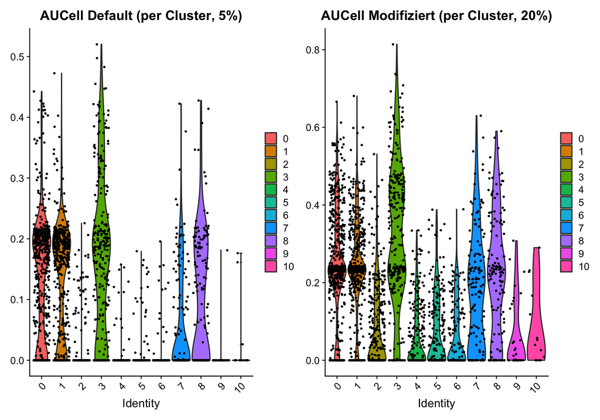

```r
p3_aucell <- VlnPlot(pbmc, features = score_name_aucell_default, group.by = "seurat_clusters", pt.size = 0.5, ncol = 1) +
  labs(title = paste0("AUCell Default (per Cluster, ", AUC_MAX_RANK_PC_DEFAULT*100, "%)"))

p4_aucell <- VlnPlot(pbmc, features = score_name_aucell_modified, group.by = "seurat_clusters", pt.size = 0.5, ncol = 1) +
  labs(title = paste0("AUCell Modifiziert (per Cluster, ", AUC_MAX_RANK_PC_MODIFIED*100, "%)"))

p3_aucell | p4_aucell
```

## 5 Zusammenfassung

| Methode | Kernprinzip | Wichtige Parameter für PLAs | Stärke | Schwäche |
| --- | --- | --- | --- | --- |
| **AddModuleScore** | Expressions-Differenz zu gematchten Kontroll-Genen | `ctrl`, `nbin` | Korrigiert Biases (z.B. Zellgröße) | Abhängig von der Qualität des Kontroll-Gen-Matchings |
| AUCell | Rang-basierter AUC-Score | `aucMaxRank` (Prozentsatz) | Sehr robust gegenüber Ausreißern und absoluten Expressionswerten | Score ist sensitiv zur Signaturgröße; muss für schwache Signale (`PLA`) angepasst werden |
| UCell | Rang-basierter AUC-Score mit Uniformity Correction | `maxRank` (absolute Zahl) | Schnell, weniger sensitiv zur Signaturgröße | Muss für schwache Signale (`PLA`) angepasst werden |

## 6 Zelltyp-spezifische Z-Score-Normalisierung

Um festzustellen, ob ein Leukocyt ein echtes Platelet-Aggregat (PLA) ist, darf ich nicht einfach den höchsten Score im ganzen Datensatz suchen. Ich muss prüfen, ob die Zelle innerhalb ihres eigenen Zelltyps eine hohe Platelet-Anreicherung aufweist.

Hier wende ich die Zelltyp-spezifische Z-Score-Normalisierung an, um festzustellen, ob die Platelet-Transkripte die erwarteten Hintergrundwerte für diesen spezifischen Zelltyp überschreiten. Ich verwende dafür den modifizierten AUCell-Score (`AUCell_Score_Modified`), da der erhöhte `aucMaxRank` diesen Score sensitiver für unser erwartetes schwaches Platelet-Signal macht.

Der Z-Score (oder Standard-Score) misst, wie viele Standardabweichungen (σ) ein individueller Roh-Score vom Mittelwert (μ) seiner Gruppe (C) entfernt ist. Ich berechne den Mittelwert (μ) und die Standardabweichung (σ) des AUCell-Scores separat für jeden Seurat-Cluster. Anschließend ziehe ich für jede Zelle ihren Cluster-Mittelwert ab und teile durch die Cluster-Standardabweichung. Dann sind alle Cluster zentriert um Null im Z-Score-Plot. Der finale Z-Score-Plot erlaubt es uns, einen klaren Schwellenwert (z.B. Z=2) festzulegen, um die potenziellen PLAs im Datensatz zu flaggen.

```r
score_to_normalize <- "AUCell_Score_Modified"
cluster_col <- "seurat_clusters"

data_for_zscore <- pbmc@meta.data %>%
  mutate(ClusterID = as.character(!!sym(cluster_col))) %>%
  select(ClusterID, Score = !!sym(score_to_normalize))

# Berechnung von mean und sd
cluster_stats <- data_for_zscore %>%
  group_by(ClusterID) %>%
  summarise(
    mean_score = mean(Score),
    sd_score = sd(Score),
    .groups = 'drop'
  )

# Z-Scores berechnen und in das Seurat-Objekt zurückschreiben
normalized_scores <- data_for_zscore %>%
  left_join(cluster_stats, by = "ClusterID") %>%
  mutate(AUCell_ZScore = (Score - mean_score) / sd_score) %>%
  select(AUCell_ZScore)

# Z-Score in die Metadaten des Seurat-Objekts einfügen
pbmc$AUCell_ZScore <- normalized_scores$AUCell_ZScore
pbmc$AUCell_ZScore[is.na(pbmc$AUCell_ZScore)] <- 0

score_name_zscore <- "AUCell_ZScore"

print(head(pbmc@meta.data[, c(cluster_col, score_to_normalize, score_name_zscore)]))
```

```
##                seurat_clusters AUCell_Score_Modified AUCell_ZScore
## AAACATACAACCAC               1             0.4368728     1.6209868
## AAACATTGAGCTAC               2             0.0000000    -0.7790490
## AAACATTGATCAGC               1             0.2783251     0.2521323
## AAACCGTGCTTCCG               4             0.0000000    -0.7007292
## AAACCGTGTATGCG               7             0.2240467     0.3192064
## AAACGCACTGGTAC               1             0.3477468     0.8514984
```

### 6.1 Visualisierung des Z-Scores

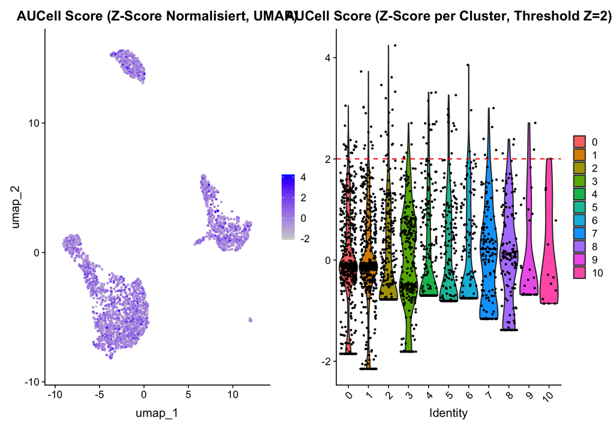

```r
# Der Z-Score ist zentriert um 0.
p1_zscore <- FeaturePlot(pbmc, features = score_name_zscore, reduction = "umap") +
  labs(title = "AUCell Score (Z-Score Normalisiert, UMAP)")

p2_zscore <- VlnPlot(pbmc, features = score_name_zscore, group.by = "seurat_clusters", pt.size = 0.5, ncol = 1) +
  geom_hline(yintercept = 2, linetype = "dashed", color = "red") + # Beispiel-Threshold zur Kennzeichnung möglicher PLAs
  labs(title = "AUCell Score (Z-Score per Cluster, Threshold Z=2)")

p1_zscore | p2_zscore
```

## 7 Mögliche Score-Modifications

### 7.1 Gewichtung der Gene (Weighted AUC)

Sowohl AUCell als auch UCell behandeln aktuell jedes Gen als gleich wichtig. Die Idee wäre jedem Platelet-Marker-Gen ein Gewicht zu zuweisen, basierend auf seiner typischen Expression in reinen Platelets (aus bulk RNA-seq oder reinen scRNA-seq Platelet-Clustern).

Um die Gewichtung der Gene in AUCell umzusetzen, müsste man die Berechnung der AUC anpassen, indem man jedem Gen g ein Gewicht wg zuweist:

1. Das Gewichtwg für jedes Platelet-Gen g definieren (basierend auf seiner Bedeutung oder Expression in reinen Platelets)
2. Rang-Score für die Zelle i berechnen, nicht nur als die Anreicherung der Gene, sondern als die gewichtete Anreicherung der Gene.

### 7.2 Hybrid-Score

Erstellung eines gewichteten Hybrid-Scores, der die Stärken von AUCell/UCell und AddModuleScore kombiniert.

$$\text{PLA}_{\text{Hybrid}} = \alpha
\cdot \text{Score}_{\text{Rang}} + \beta \cdot
\text{Score}_{\text{Expression}}$$

Das involviert:

1. Berechnung des Rang-basierten Scores mit AUCell
2. Berechnung des normierten Expressions-Scores (AddModuleScore)
3. Kombinieren beider Scores

Die Herausforderung liegt dann in der Wahl von alpha und beta. Man könnte α=0.7 und β=0.3 wählen, um den Rang-Score stärker zu gewichten, da dieser robuster ist.